# Indel Signature InsDel6

# InsDel6

(corresponds to 83-type signature C_ID6)

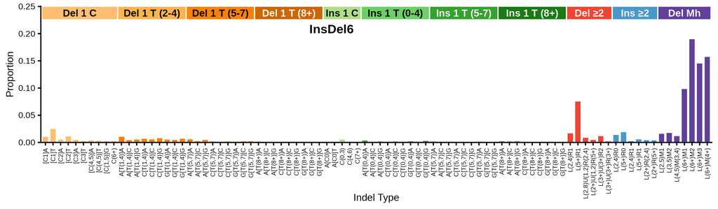

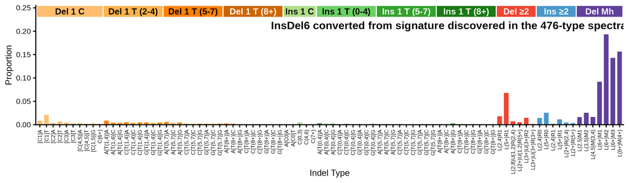

89-type spectrum of the linking tumor SP102035 | cosine similarity to InsDel6: 0.9949

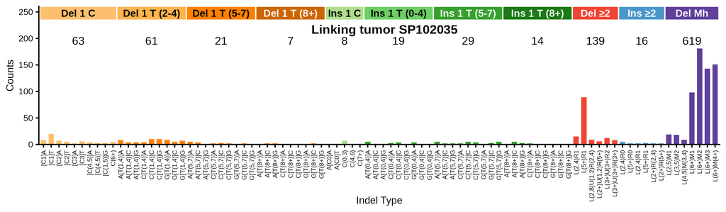

**Click to view decomposition of the linking tumor spectrum**

Partial mutation signature of SP102035 due to InsDel6

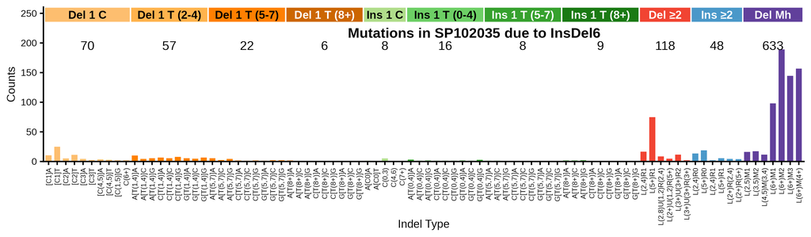

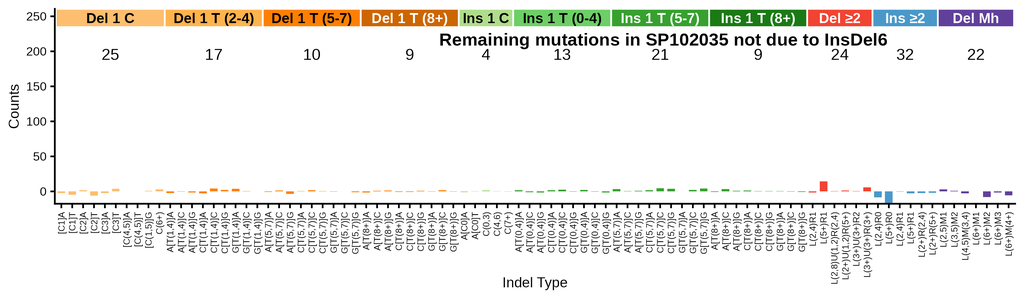

Max neg fraction (maximum allowed negative residual count as fraction of total): 0.15  
N subtract (mutation count assigned to signature): 996.0  
N residual (mutation count in residual “partial spectrum”): 0.0  
Total negative (sum of negative residual mutation counts): 93.2  
N negative channels (number of channels with negative residual): 42  
P(≥ total negative) (Monte Carlo estimated probability that negative-binomial-sampled spectra from the signature contributing N subtract mutations would produce a total negative count >= the observed Total negative; higher number means not surprising): 0.879

**Per-channel residual breakdown**

| Channel | Spectrum | Sig_Count | Residual | Sig_Prop |
| --- | --- | --- | --- | --- |
| [Del(C):R1]A | 8 | 10.4 | -2.4 | 0.01046 |
| [Del(C):R1]T | 20 | 24.8 | -4.8 | 0.02489 |
| [Del(C):R2]A | 7 | 5.2 | 1.8 | 0.00519 |
| [Del(C):R2]T | 5 | 11.1 | -6.1 | 0.01117 |
| [Del(C):R3]A | 2 | 4.4 | -2.4 | 0.00444 |
| [Del(C):R3]T | 6 | 2.4 | 3.6 | 0.00245 |
| [Del(C):R(4,5)]A | 4 | 3.8 | 0.2 | 0.00377 |
| [Del(C):R(4,5)]T | 3 | 3.0 | 0 | 0.00302 |
| [Del(C):R(1,5)]G | 3 | 2.3 | 0.7 | 0.00226 |
| Del(C):R(6,9) | 5 | 2.2 | 2.8 | 0.00222 |
| A[Del(T):R(1,4)]A | 8 | 10.2 | -2.2 | 0.01028 |
| A[Del(T):R(1,4)]C | 4 | 4.3 | -0.3 | 0.00434 |
| A[Del(T):R(1,4)]G | 4 | 5.4 | -1.4 | 0.00542 |
| C[Del(T):R(1,4)]A | 4 | 6.8 | -2.8 | 0.00681 |
| C[Del(T):R(1,4)]C | 10 | 5.7 | 4.3 | 0.00570 |
| C[Del(T):R(1,4)]G | 10 | 7.8 | 2.2 | 0.00787 |
| G[Del(T):R(1,4)]A | 9 | 5.4 | 3.6 | 0.00543 |
| G[Del(T):R(1,4)]C | 5 | 4.6 | 0.4 | 0.00461 |
| G[Del(T):R(1,4)]G | 7 | 6.8 | 0.2 | 0.00682 |
| A[Del(T):R(5,7)]A | 5 | 5.7 | -0.7 | 0.00570 |
| A[Del(T):R(5,7)]C | 4 | 2.5 | 1.5 | 0.00252 |
| A[Del(T):R(5,7)]G | 1 | 4.5 | -3.5 | 0.00452 |
| C[Del(T):R(5,7)]A | 2 | 1.5 | 0.5 | 0.00155 |
| C[Del(T):R(5,7)]C | 3 | 1.2 | 1.8 | 0.00118 |
| C[Del(T):R(5,7)]G | 2 | 1.6 | 0.4 | 0.00162 |
| G[Del(T):R(5,7)]A | 1 | 1.3 | -0.3 | 0.00132 |
| G[Del(T):R(5,7)]C | 2 | 1.9 | 0.1 | 0.00195 |
| G[Del(T):R(5,7)]G | 1 | 2.1 | -1.1 | 0.00212 |
| A[Del(T):R(8,)]A | 0 | 1.7 | -1.7 | 0.00174 |
| A[Del(T):R(8,)]C | 2 | 1.1 | 0.9 | 0.00107 |

[output cut: 59 more lines]

**Click to view similar signatures from Koh et al.**

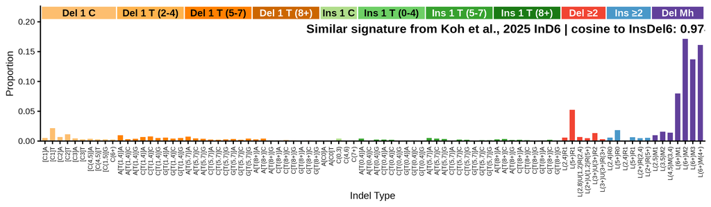

## 476-type representations corresponding to InsDel6

Extracted 476-type signature corresponding to InsDel6

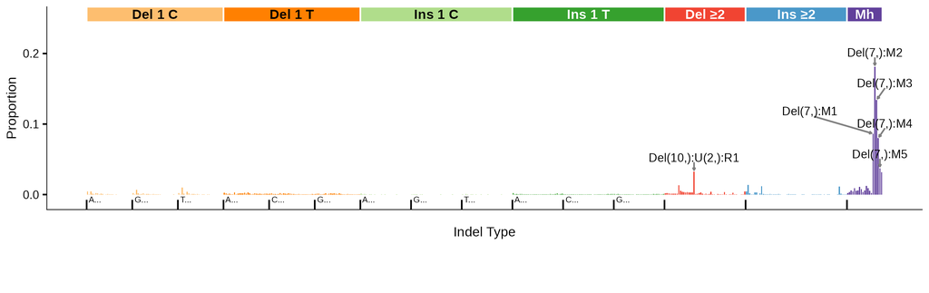

476-type spectrum of the linking tumor SP102035; cosine similarity to the extracted 476-type signature is 0.9915

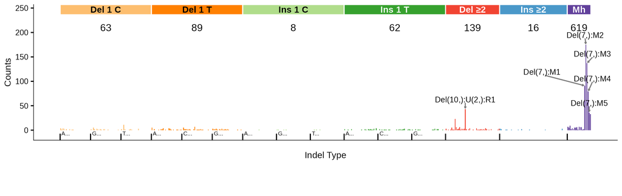

476-type spectrum of best 476-type matching tumor SP67609; cosine similarity to the extracted 476-type signature is 0.9939

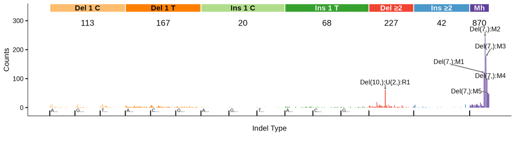

## 83-type signature corresponding to InsDel6 (C_ID6)

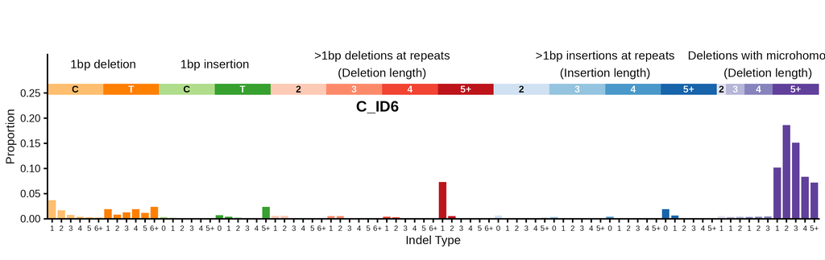

83-type signature converted from signature discovered in the 476-type spectra (using bipartite matching optimization) | cosine similarity to C_ID6: 0.9978

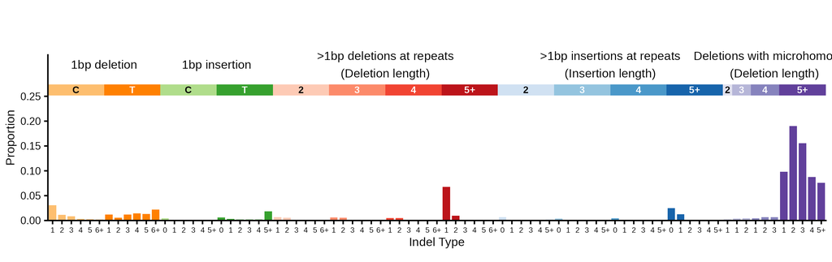

**Click to see flow diagrams: 476-type to 83-type collapse**

These Sankey diagrams show how the 476-type mutation categories are redistributed to 83-type categories using bipartite matching. We only show the diagrams for insertions or deletions of > 1 base because it is for these indels that 476-type categories map to > 1 83-type category.

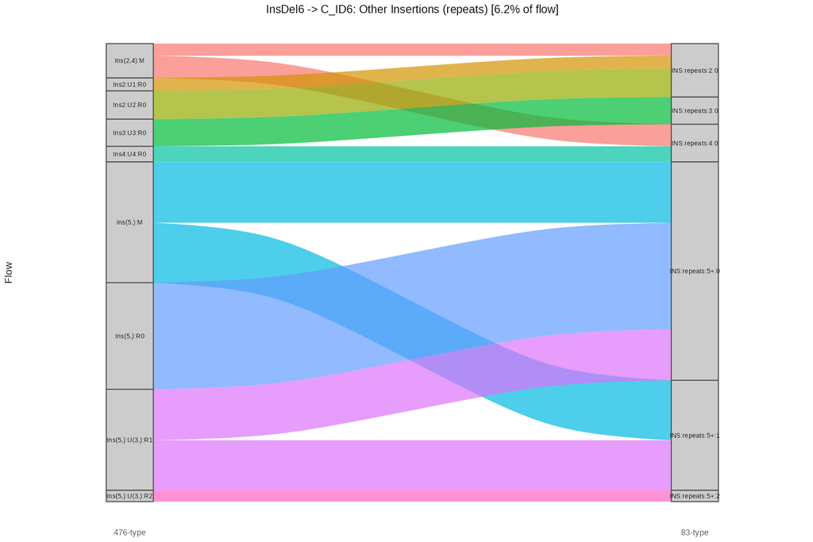

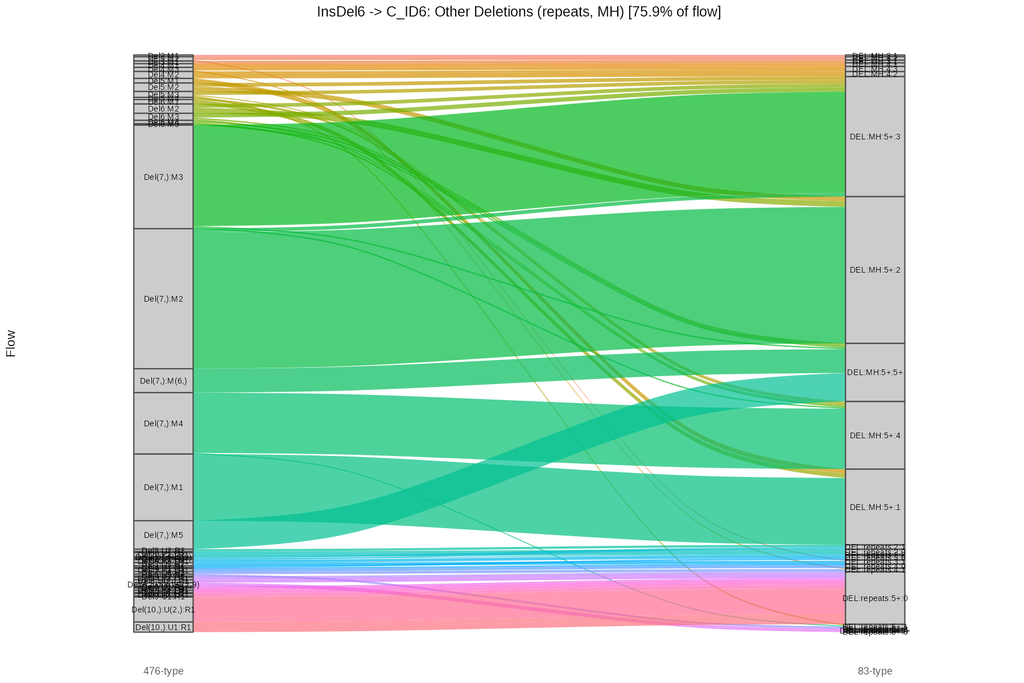

83-type spectrum of the linking tumor SP102035 | cosine similarity to C_ID6: 0.9925

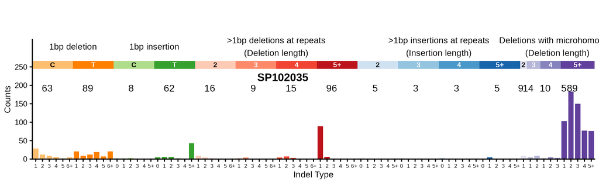

83-type spectrum of best 83-type matching tumor SP67609 | cosine similarity to C_ID6: 0.9953

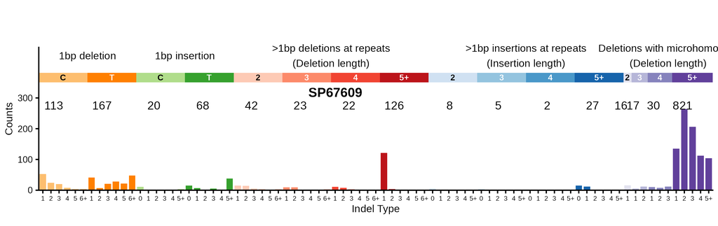

### Similar COSMIC signatures

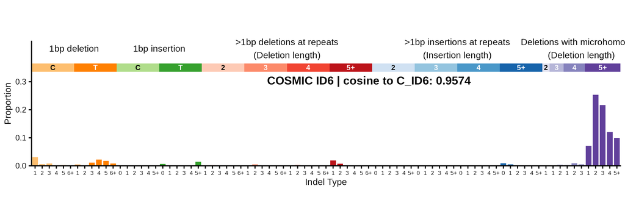

### Similar signatures from Jin et al. 2024

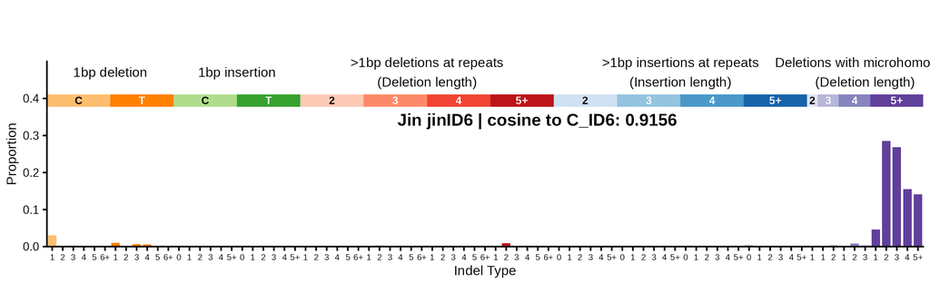